# A Simple MCMC demonstration

Clay Ford

2024-02-06

Note: This demo borrows extensively from the following blog post: [A simple Metropolis-Hastings MCMC in R](https://theoreticalecology.wordpress.com/2010/09/17/metropolis-hastings-mcmc-in-r/). The only difference is I simplified the example to estimate a posterior distribution for a proportion instead of a linear model. I’ve also tried to add a bit more exposition. This is only for educational purposes. MCMC is not necessary to estimate the posterior distribution of a proportion.

## Generate some data

Let’s generate some data from a binomial distribution with size = 1 and prob = 0.3. This generates a sequence of zeroes and ones, where ones have a probability of 0.3 occurring.

```r
set.seed(1)
y <- rbinom(n = 50, size = 1, prob = 0.3)
y
```

```
##  [1] 0 0 0 1 0 1 1 0 0 0 0 0 0 0 1 0 1 1 0 1 1 0 0 0 0 0 0 0 1 0 0 0 0 0 1 0 1 0
## [39] 1 0 1 0 1 0 0 1 0 0 1 0
```

Now pretend we came upon this data naturally through an experiment or observation and want to use Bayesian statistics to estimate the probability of a 1 occurring. Perhaps we randomly surveyed college students and asked them if they had an Apple computer, where 1 = yes and 0 = no. This is our parameter of interest: the probability of having an Apple computer.

The Frequentist approach can be carried out using the `prop.test()` function:

```r
prop.test(x = sum(y), n = length(y), correct = FALSE)
```

```
##
##  1-sample proportions test without continuity correction
##
## data:  sum(y) out of length(y), null probability 0.5
## X-squared = 6.48, df = 1, p-value = 0.01091
## alternative hypothesis: true p is not equal to 0.5
## 95 percent confidence interval:
##  0.2075822 0.4581030
## sample estimates:
##    p
## 0.32
```

We estimate the proportion of students with Apple computers to be about 0.32 with a 95% confidence interval of [0.21, 0.46].

Bayesian inference does not make a point estimate of the parameter, but instead estimates the *probability distribution* of possible values for the parameter. This is the *posterior distribution*.

Now we use Markov Chain Monte Carlo to work “backwards” and estimate a posterior probability distribution for the parameter of interest.

## The likelihood

First we define the likelihood, which is our model. Notice we’re fitting the correct model using the `dbinom()` function. We simulated data from a binomial dist with `rbinom()`, and now we’re modeling the probability of ones using a binomial distribution. We estimate the probability of getting a 0 or 1 for different parameter values, convert to log, and sum up. This is the log likelihood. In frequentist statistics we try to maximize the log likelihood.

```r
likelihood <- function(param){
  singlelikelihoods <- dbinom(y, size = 1, prob = param, log = TRUE)
  sumll <- sum(singlelikelihoods)
  sumll
  }
```

Notice the likelihood is much higher for 0.28 than for 0.98.

```r
likelihood(0.28)
```

```
## [1] -31.53659
```

```r
likelihood(0.98)
```

```
## [1] -133.332
```

We can also plot the likelihood for a range of probability values. Below we run parameter values ranging from 0.01 to 0.99 through the function and plot the results versus the parameter values.

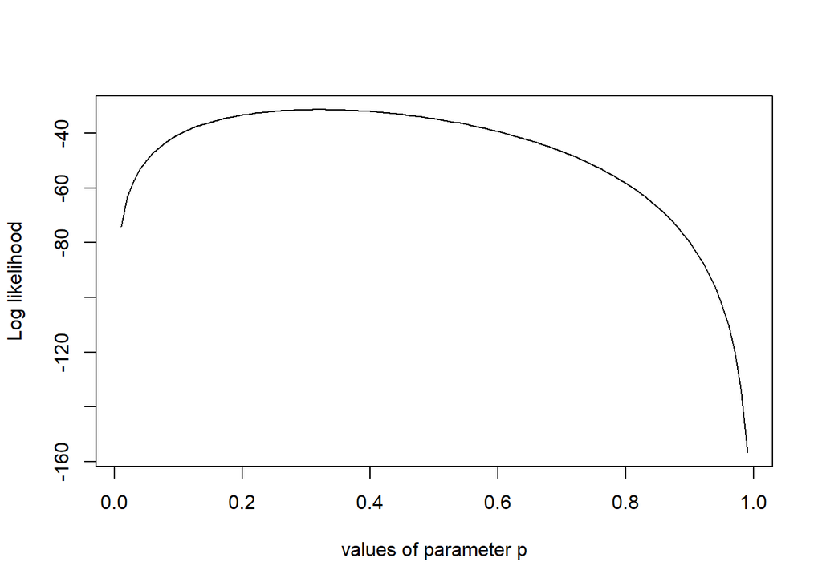

```r
p <- seq(0.01, 0.99, by=.01)
p_likelihoods = sapply(p, likelihood)
plot(p, p_likelihoods , type="l",
     xlab = "values of parameter p", ylab = "Log likelihood")
```

Notice the maximum value is at 0.32.

```r
p[which.max(p_likelihoods)]
```

```
## [1] 0.32
```

This is simply the proportion of ones.

```r
sum(y)/length(y)
```

```
## [1] 0.32
```

## The prior distribution

Bayesian inference uses the likelihood to update a prior distribution for the parameter. We have to provide the prior distribution. Let’s define a prior distribution for our parameter of interest. Perhaps prior surveys indicated about 0.4 of students use Apple computers. We define our prior as Normal distribution with mean 0.4 and standard deviation 0.15.

Here’s what the prior distribution looks like:

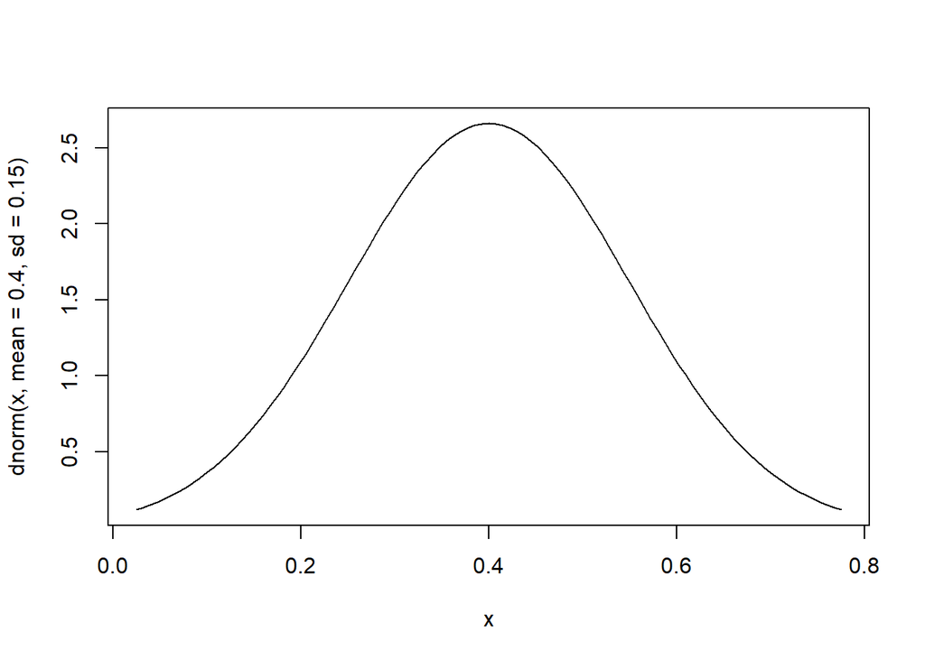

```r
curve(dnorm(x, mean = 0.4, sd = 0.15),
      from = 0.4 - 2.5*0.15,
      to = 0.4 + 2.5*0.15)
```

We define a prior distribution *function* which returns the density for a proposed parameter using the *prior distribution parameters*. Notice we also convert to the log scale by setting `log = TRUE`.

```r
prior <- function(param){
  dnorm(param, mean = 0.4, sd = 0.15, log = TRUE)
  }
```

For example, if the proposed parameter is 0.33…

```r
prior(0.33)
```

```
## [1] 0.8692926
```

The density for the prior distribution is about 0.87.

## The posterior distribution

Now we create a posterior function that is the sum of the likelihood and prior. Why sum? Because the sum of logs is equal to the log of products. Summing log transformed values is safer numerically as products of many small values can result in values with many, many decimals. Our computers can only be so precise.

```r
posterior <- function(param){
  likelihood(param) + prior(param)
  }
```

For example, if the proposed parameter is 0.33…

```r
posterior(0.33)
```

```
## [1] -30.48555
```

The density for the posterior distribution is about -30.5.

This is the distribution we’ll sample from. Now we’re ready to do the MCMC sampling.

## The Metropolis algorithm

To quote [Wikipedia](https://en.wikipedia.org/wiki/Metropolis%E2%80%93Hastings_algorithm): “the Metropolis–Hastings algorithm is a Markov chain Monte Carlo (MCMC) method for obtaining a sequence of random samples from a probability distribution **from which direct sampling is difficult**.” (emphasis mine.)

We define a function to execute the Metropolis algorithm that has two arguments: `startvalue` and `iterations`. The `startvalue` is the first sample we draw from the posterior. It primes the pump. The iterations is the number of samples we wish to draw. We want to draw a lot of samples, like in the thousands.

```r
run_metropolis_MCMC = function(startvalue, iterations){

  # initiate a vector with iterations + 1 elements
  chain <- vector(mode = "numeric", length = iterations + 1)

  # set the starting value
  chain[1] <- startvalue

  # begin the MCMC sampling
  for (i in 1:iterations){

    # propose a new sample value based on current sample;
    # draw new sample from N(0,2.5) dist'n;
    # plogis() is the inverse logit that converts (-Inf,Inf) to (0,1);
    # this ensures we propose a proportion
    proposal <- plogis(rnorm(n = 1, mean = chain[i], sd = 2.5))

    # calculate an acceptance ratio called "probab"
    probab <- exp(posterior(proposal) - posterior(chain[i]))

    # draw a random value between 0 and 1;
    # if value is less than the acceptance ratio, keep the proposed sample
    if (runif(1) < probab){
      chain[i+1] <- proposal

    # otherwise reject the proposed sample and keep previous sample
    }else{
      chain[i+1] <- chain[i]
    }

    # repeat this process, which amazingly works.
  }
  chain
}
```

Now run the MCMC sampling for 10,000 iterations with `startvalue` set to 0.5

```r
startvalue <- 0.5
chain <- run_metropolis_MCMC(startvalue, 10000)
```

Let’s throw out the first 5000 samples as burn-in and only keep the last 5000 samples.

```r
burnIn <- 5000
posterior_sample <- chain[-(1:burnIn)]
```

Now calculate the median and 95% uncertainty interval of the posterior distribution.

```r
median(posterior_sample)
```

```
## [1] 0.3332564
```

```r
quantile(posterior_sample, probs = c(0.025, 0.975))
```

```
##      2.5%     97.5%
## 0.2229626 0.4563931
```

We can also plot the posterior distribution.

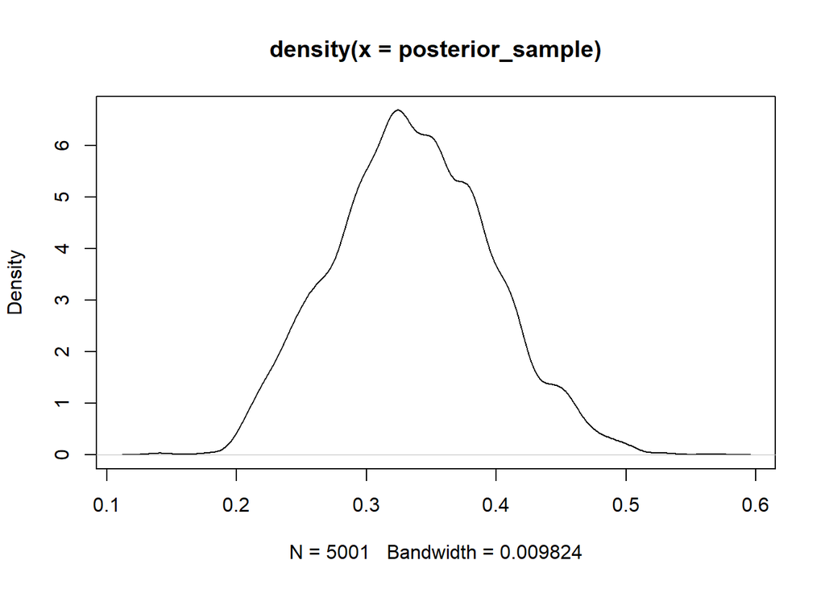

```r
plot(density(posterior_sample))
```

Compare to rstanarm results which uses a more sophisticated sampling algorithm called “Hamiltonian Monte Carlo”. Notice the posterior distribution is much smoother despite the fact it’s based only on 4000 samples instead of 5000.

```r
library(rstanarm)
m <- stan_glm(y ~ 1, family = binomial, refresh = 0)
plogis(coef(m))
```

```
## (Intercept)
##   0.3211694
```

```r
plogis(posterior_interval(m, prob = 0.95))
```

```
##                  2.5%     97.5%
## (Intercept) 0.2088511 0.4532054
```

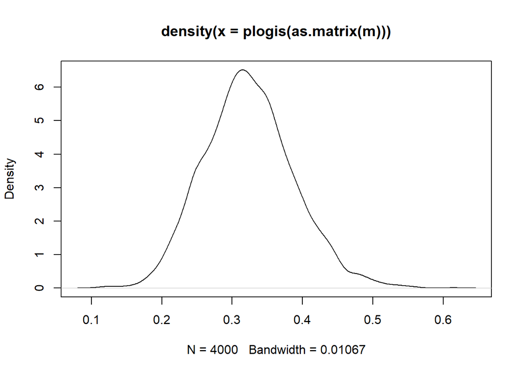

```r
plot(density(plogis(as.matrix(m))))
```